# Olympics EDA

In this file we are going to explore the data and find out the insights in our data.

First of all we are going to load the data and look at the summary

```
##        ID                               Name        Sex
##  Min.   :     1   Robert Tait McKenzie    :    58   F: 74522
##  1st Qu.: 34643   Heikki Ilmari Savolainen:    39   M:196594
##  Median : 68205   Joseph "Josy" Stoffel   :    38
##  Mean   : 68249   Ioannis Theofilakis     :    36
##  3rd Qu.:102097   Takashi Ono             :    33
##  Max.   :135571   Alexandros Theofilakis  :    32
##                   (Other)                 :270880
##       Age            Height          Weight                 Team
##  Min.   :10.00   Min.   :127.0   Min.   : 25.0   United States: 17847
##  1st Qu.:21.00   1st Qu.:168.0   1st Qu.: 60.0   France       : 11988
##  Median :24.00   Median :175.0   Median : 70.0   Great Britain: 11404
##  Mean   :25.56   Mean   :175.3   Mean   : 70.7   Italy        : 10260
##  3rd Qu.:28.00   3rd Qu.:183.0   3rd Qu.: 79.0   Germany      :  9326
##  Max.   :97.00   Max.   :226.0   Max.   :214.0   Canada       :  9279
##  NA's   :9474    NA's   :60171   NA's   :62875   (Other)      :201012
##       NOC                 Games             Year         Season
##  USA    : 18853   2000 Summer: 13821   Min.   :1896   Summer:222552
##  FRA    : 12758   1996 Summer: 13780   1st Qu.:1960   Winter: 48564
##  GBR    : 12256   2016 Summer: 13688   Median :1988
##  ITA    : 10715   2008 Summer: 13602   Mean   :1978
##  GER    :  9830   2004 Summer: 13443   3rd Qu.:2002
##  CAN    :  9733   1992 Summer: 12977   Max.   :2016
##  (Other):196971   (Other)    :189805
##              City               Sport
##  London        : 22426   Athletics : 38624
##  Athina        : 15556   Gymnastics: 26707
##  Sydney        : 13821   Swimming  : 23195
##  Atlanta       : 13780   Shooting  : 11448
##  Rio de Janeiro: 13688   Cycling   : 10859
##  Beijing       : 13602   Fencing   : 10735
##  (Other)       :178243   (Other)   :149548
##                                  Event           Medal
##  Football Men's Football            :  5733   Bronze: 13295
##  Ice Hockey Men's Ice Hockey        :  4762   DNW   :231333
##  Hockey Men's Hockey                :  3958   Gold  : 13372
##  Water Polo Men's Water Polo        :  3358   Silver: 13116
##  Basketball Men's Basketball        :  3280
##  Cycling Men's Road Race, Individual:  2947
##  (Other)                            :247078
##      region                         notes
##  USA    : 18853                        :266077
##  Germany: 15883   Yugoslavia           :  2583
##  France : 12758   Hong Kong            :   685
##  UK     : 12256   Trinidad and Tobago  :   375
##  Russia : 11692   Serbia and Montenegro:   321
##  Italy  : 10715   Virgin Islands       :   294
##  (Other):188959   (Other)              :   781
```

Now that we have data. We are going to take a look at each column independently

## Univariant Analysis

### Sex

```
##      F      M
##  74522 196594
```

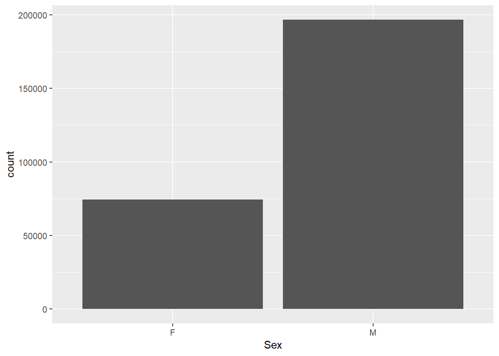

Here we see that number of female atheletes are less than number of male athletes in olympic.

### Age

We know that there are missing values in our Age, Height and Weight Category I am going to leave those values and plot the data that we have.

```
##    Min. 1st Qu.  Median    Mean 3rd Qu.    Max.    NA's
##   10.00   21.00   24.00   25.56   28.00   97.00    9474
```

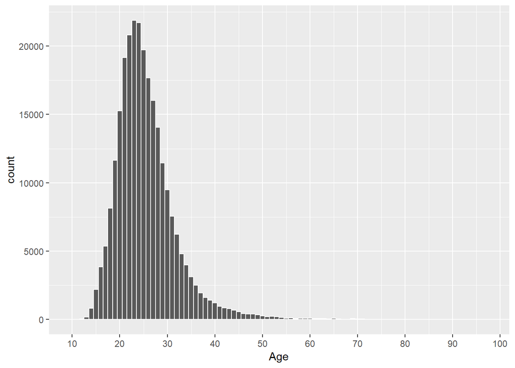

Based on the data available we can say that most of the athletes we have are young, with max altheletes of age 24

### Height

```
##    Min. 1st Qu.  Median    Mean 3rd Qu.    Max.    NA's
##   127.0   168.0   175.0   175.3   183.0   226.0   60171
```

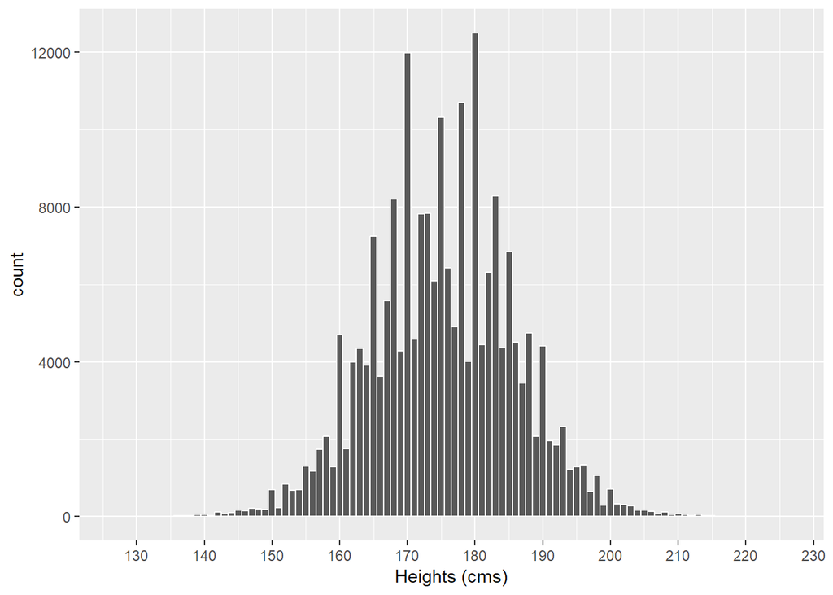

### Weight

```
##    Min. 1st Qu.  Median    Mean 3rd Qu.    Max.    NA's
##    25.0    60.0    70.0    70.7    79.0   214.0   62875
```

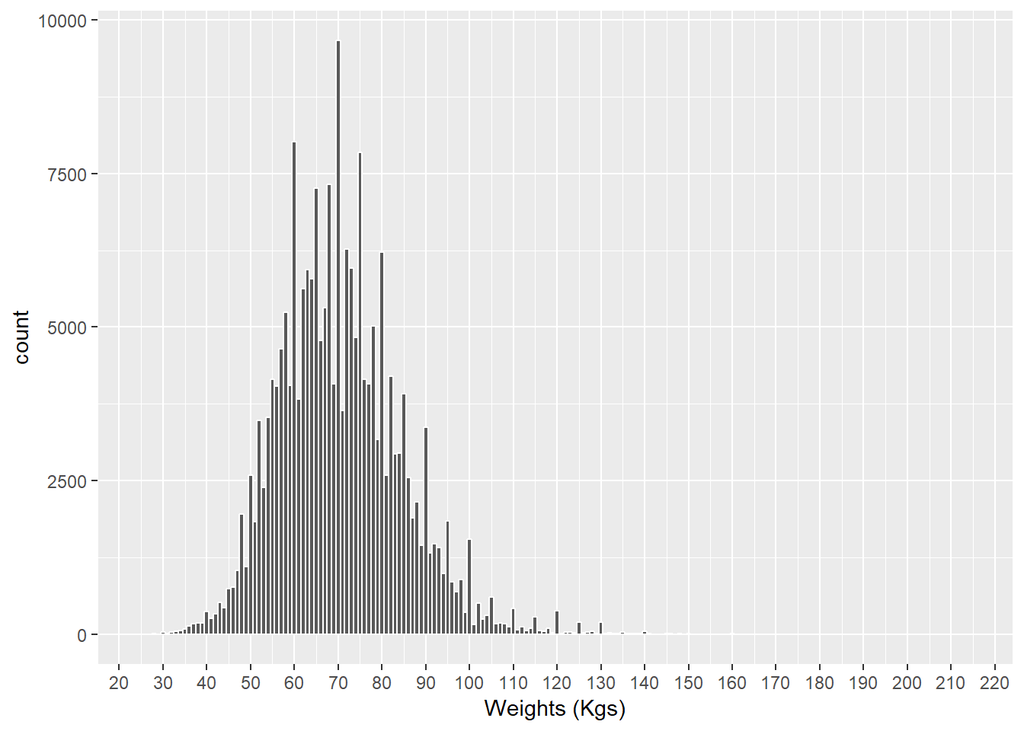

The max value for the weiht is 214, but most of the values lie between 30 and 130. Again we see spikes at multiples of 10 and small spikes at multiples of 5.

### Team

Team is the name of the team athelete belongs to.

```
## [1] 1184
```

So we have 1184 total teams in olympics.

```
## [1] "Top 10 Team in terms of participation"
```

```
##
## United States        France Great Britain         Italy       Germany
##         17847         11988         11404         10260          9326
##        Canada         Japan        Sweden     Australia       Hungary
##          9279          8289          8052          7513          6547
```

```
## x
##   1   2   3   4   5   6   7   8   9  10
## 103 265 168  75  87  57  15  25  23  27
```

### Sport

```
## [1] "Number of sports"
```

```
## [1] 66
```

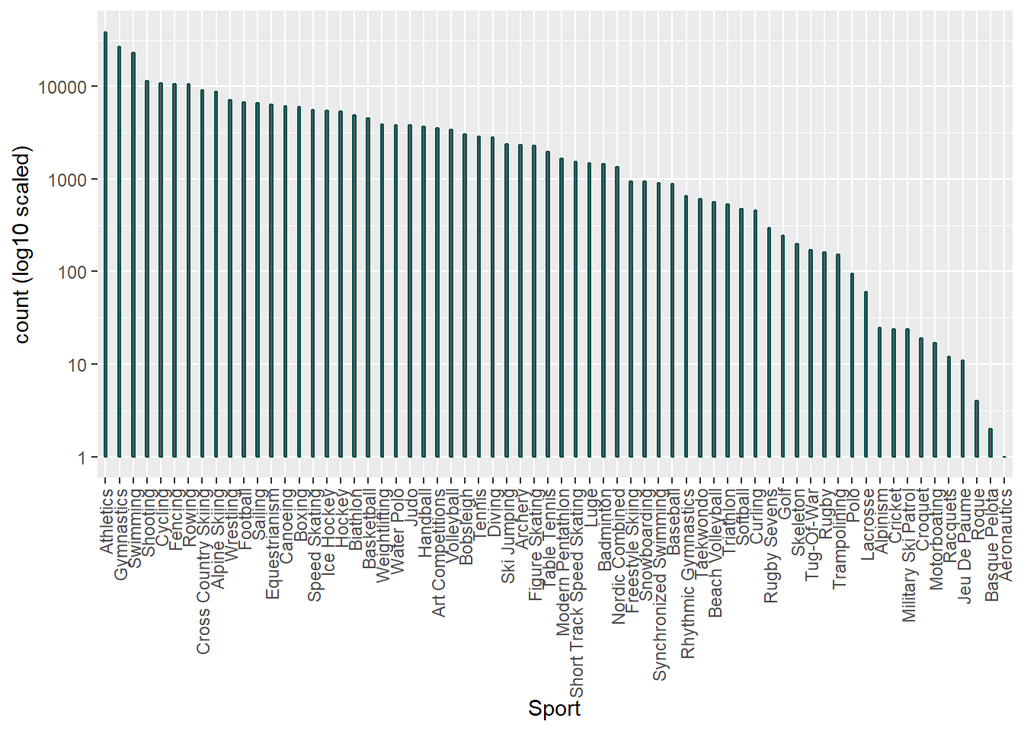

In this graph we can see the paticipation of athletes in Sports. Aeronautics has the least number of participants ,only 1 and Athletics has maximum number of participants.

### Medals

We have three type of medals Gold, Silver and Bronze, If an athlete did not win medal then DNW

I am going to plot only the Medal data when the athlete won

```
## [1] 39783
```

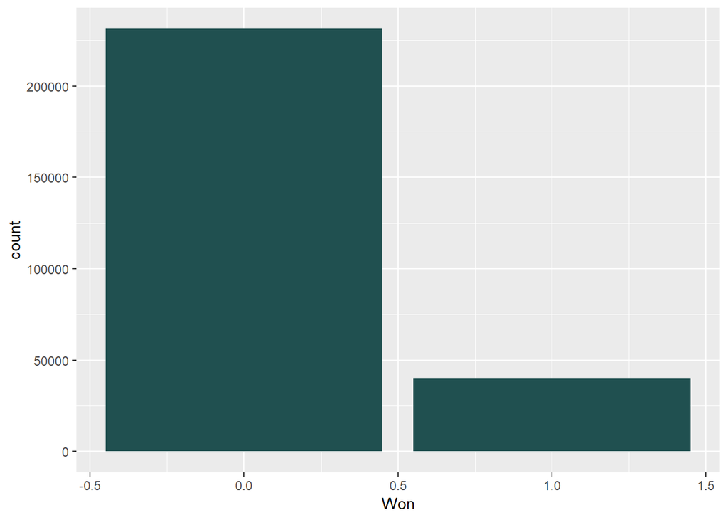

```
##   Gold Silver Bronze    DNW
##  13372  13116  13295 231333
```

The number of Gold, Silver and Bronze medals are not same, there is a difference of a few 100s.

## Bivariant Analysis

In this session we are going to take a look at relation between two variables

### Number of Male and Female athlete over the years

We are going to plot how the number of male and female athlete participation changed over the year

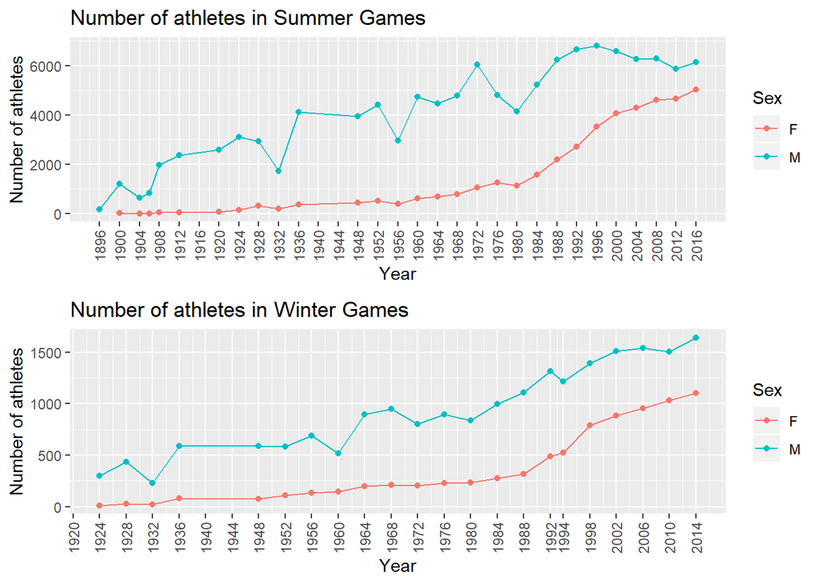

In the first Olympics games we have no women athlete. But after that we see a grdual increae in women athlete It is very low in the begining and then we see a big rise in 80s.

We also have some missin games 1916 summer, 1940-1944 summer and winter. These are the times of World wars and the games were cancelled.

Also there is a shoft in years of winter olympics. In 1994 the winter olympic year moved to 2 years after summer oympics. And before 1924 we didn’t have winter olympics.

We see that the gap in number of male and female athletes in descresing over the years.

### Number of countries particiapted

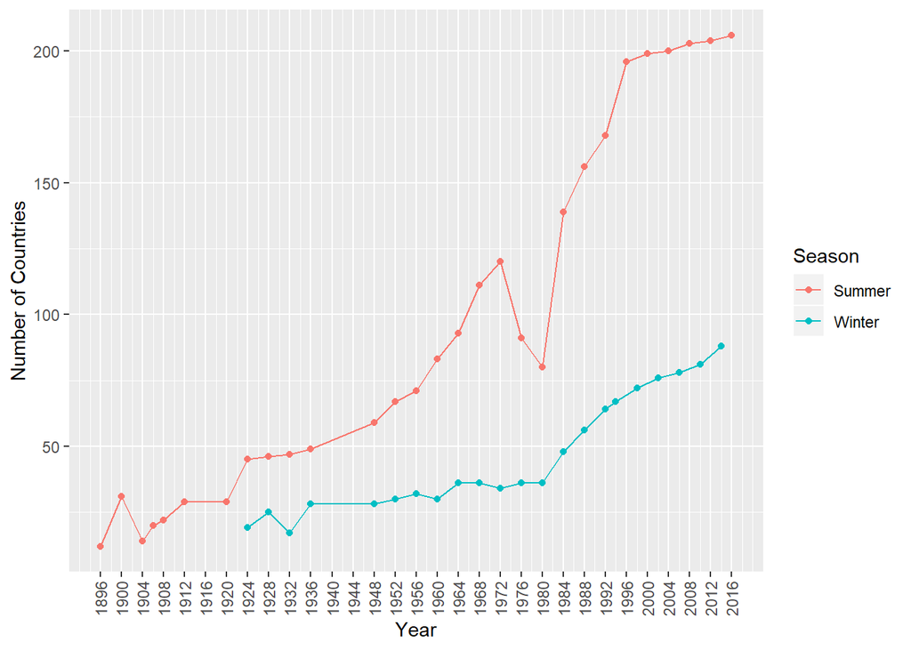

Over the years games saw an increse in number of countries. But in year 1980 we see a shape decline in summer games. this is the same decline we saw in number of athletes too.

This is because the Soviet Union invaded Afghanistan and 1980 games were held in Soviet Union. United States initiated the boycot of games as a protest against invasion.

### countries and Medals

Now we are going to check if there are any countries that never won any medal at all, won other but never won gold medal, where either men or women never won gold medal.

```
## [1] "Countries with no medal"
```

```
##  [1] Albania                          American Samoa
##  [3] Andorra                          Angola
##  [5] Antigua                          Aruba
##  [7] Bangladesh                       Belize
##  [9] Benin                            Bhutan
## [11] Boliva                           Bosnia and Herzegovina
## [13] Brunei                           Burkina Faso
## [15] Cambodia                         Cape Verde
## [17] Cayman Islands                   Central African Republic
## [19] Chad                             Comoros
## [21] Cook Islands                     Democratic Republic of the Congo
## [23] Dominica                         El Salvador
## [25] Equatorial Guinea                Gambia
## [27] Guam                             Guinea
## [29] Guinea-Bissau                    Honduras
```

[output cut: 22 more lines]

```
## [1] "Countries with no Gold medal but others"
```

```
##  [1] Ghana        Iceland      Kyrgyzstan   Lebanon      Malaysia
##  [6] Moldova      Niger        Philippines  Qatar        Saudi Arabia
## [11] Zambia
## 209 Levels: Afghanistan Albania Algeria American Samoa Andorra ... Zimbabwe
```

```
## [1] "countries where women never won gold medal but men has"
```

```
##  [1] Armenia                     Burundi
##  [3] Chile                       Dominican Republic
##  [5] Ecuador                     Egypt
##  [7] Fiji                        Georgia
##  [9] Grenada                     Haiti
## [11] India                       Individual Olympic Athletes
## [13] Iran                        Israel
## [15] Ivory Coast                 Jordan
## [17] Latvia                      Luxembourg
## [19] Mongolia                    Nepal
## [21] Pakistan                    Panama
## [23] Peru                        Singapore
## [25] Suriname                    Tajikistan
## [27] Trinidad                    Tunisia
## [29] Uganda                      United Arab Emirates
## [31] Uruguay                     Venezuela
## [33] Vietnam
## 209 Levels: Afghanistan Albania Algeria American Samoa Andorra ... Zimbabwe
```

```
## [1] "countries where men never won gold medal but women has"
```

```
## [1] Bahrain       Costa Rica    Kosovo        Liechtenstein Mozambique
## [6] Puerto Rico   Syria         Zimbabwe
## 209 Levels: Afghanistan Albania Algeria American Samoa Andorra ... Zimbabwe
```

So we have 72 nations that never won any medal. 11 countries never won a gold medal but they have won others. In 33 countries women never won Gold medals but men have. In 8 countries men never won Gold medals but women have.

## Conclusion

1. Number of athletes incresed over the years. During the first year we did not had women athletes but then the numbers increased over the years
2. The number of countries participatin in Olympics also increased, but in year 1980 because of the boycott.
3. 72 nations never won any medal in Olympics
4. 11 countries never won gold medals but have won others
5. In 33 countries women have never won gold medals but men have
6. In 8 countries men have never won gold medals but women have

Now that we have these results from our Data Explorarion, I am going to save medal data to seaprate files for the visualizations